# mRNA distributions in yeast for constitutive and bursty genes

© 2021 Rebecca Rousseau. This work is licensed under a [Creative Commons Attribution License CC-BY 4.0](https://creativecommons.org/licenses/by/4.0/). All code contained herein is licensed under an [MIT license](https://opensource.org/licenses/MIT).

**Objective**: In this notebook, we will analyze mRNA count distributions calculated from yeast gene data (adapted from [this paper](https://www.nature.com/articles/nsmb.1514)) and fit appropriate probability distributions to the resulting plots. The chosen genes highlight constitutive and "bursty" gene transcription.

```python
# Import modules

import matplotlib.pyplot as plt
import numpy as np
import pandas as pd
import panel as pn
pn.extension()

import scipy.special as spec

import scipy.stats as stats

import seaborn as sns
sns.set()
# Enable high resolution graphics inline
%config InlineBackend.figure_format = 'retina'
```

# MDN1 mRNA count distribution (constitutive)

```
    mRNA_count  probability     error
0            0     0.003460  0.006055
1            1     0.027682  0.018166
2            2     0.040657  0.025087
3            3     0.092561  0.038062
4            4     0.124567  0.032872
5            5     0.172145  0.043253
6            6     0.149654  0.025952
7            7     0.109862  0.048443
8            8     0.116782  0.044118
9            9     0.074394  0.038062
10          10     0.035467  0.035467
11          11     0.021626  0.008651
12          12     0.015571  0.009516
13          13     0.014706  0.012976
14          14     0.004325  0.008651
15          15     0.000865  0.004325
```

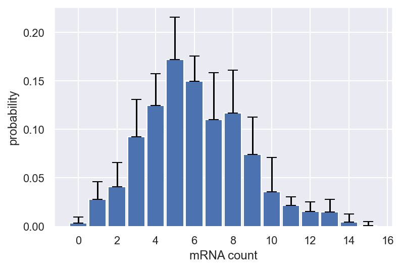

```python
data = pd.read_csv('data/mRNA_MDN1.csv')
df = pd.DataFrame(data, columns= ['mRNA_count','probability','error'])
print(df)

plt.bar(df.mRNA_count, df.probability, width=0.9)
plotline, caplines, barlinecols = plt.errorbar(df.mRNA_count, df.probability,
             yerr= df.error,
             ecolor='black',
             capsize=5,
             lolims=True,
             fmt='none',)
caplines[0].set_marker('_')
plt.xlabel('mRNA count')
_ = plt.ylabel('probability')
```

Poisson distribution for probability of $k$ counts: $$ P(X=k) = \frac{\lambda^k e^{-\lambda}}{k!}$$

```python
# Define chi-squared error function

def err(dat, count, rate):
    """
    Returns the sum of the errors for the theory curve (given the provided rate parameter)
    versus the provided data (dat). Note that the rate parameter lambda is equivalent to the mean and variance.
    """
    theory = ((rate**count) * np.exp((-1)*rate))/spec.factorial(count)
    return np.sum((theory - dat)**2)
```

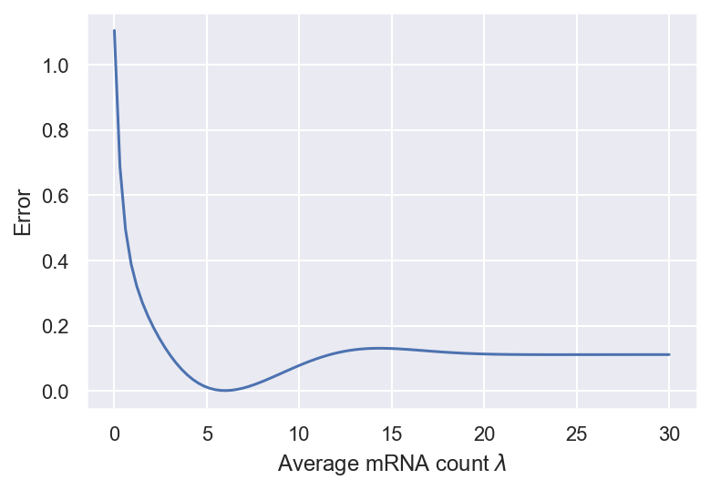

```python
# Determine error for a range of possible lambdas

# Number of points to plot
n_points = 100

# Range of lambdas to test
lambdas = np.linspace(0, 30, n_points)

# Initialize an array of error
errors = np.zeros(n_points)

# For each lambda, call our err funtion to determine the amount of error
for i in range(n_points):
    errors[i] = err(df.probability, df.mRNA_count, lambdas[i])

# Plot the errors over the values of lambda
plt.plot(lambdas, errors)
plt.ylabel('Error')
plt.xlabel('Average mRNA count $\lambda$')
plt.show()
```

To find the exact value of $\lambda$ with minimum error,

```
[6.06060606]
```

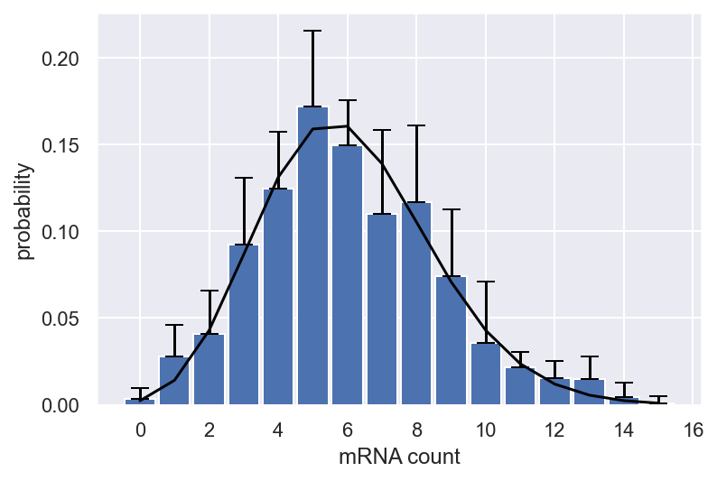

```python
# Index of the optimal lambda
ind_optimal = np.where(errors == np.min(errors))

# Optimal lambda
lambda_fit = lambdas[ind_optimal]

# Show the optimal fit
print(lambda_fit)

# Plot histogram with optimal Poisson fit
plt.bar(df.mRNA_count, df.probability, width=0.9)
plotline, caplines, barlinecols = plt.errorbar(df.mRNA_count, df.probability,
             yerr= df.error,
             ecolor='black',
             capsize=5,
             lolims=True,
             fmt='none',)
caplines[0].set_marker('_')
plt.plot(df.mRNA_count, ((lambda_fit**df.mRNA_count) * np.exp((-1)*lambda_fit))/spec.factorial(df.mRNA_count), \
            color = 'black')
plt.xlabel('mRNA count')
_ = plt.ylabel('probability')
```

# PDR5 mRNA count distribution (bursty transcription)

```
    mRNA_count  probability     error
0            0     0.007862  0.007448
1            1     0.007034  0.007448
2            2     0.013655  0.013241
3            3     0.033517  0.031862
4            4     0.035172  0.010759
5            5     0.052966  0.024000
6            6     0.053793  0.008276
7            7     0.067034  0.036828
8            8     0.064552  0.033517
9            9     0.052552 -0.000414
10          10     0.052138  0.019034
11          11     0.059586  0.034345
12          12     0.060828  0.015310
13          13     0.050483  0.028966
```

[output cut: 31 more lines]

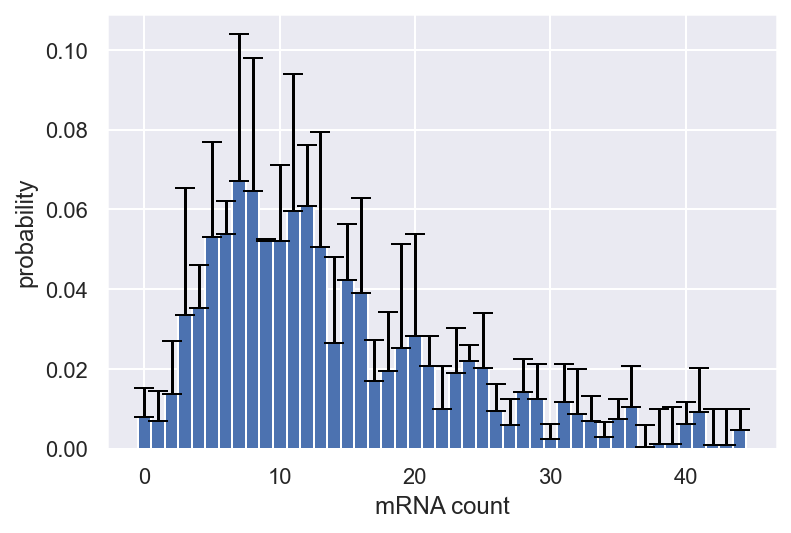

```python
data_P = pd.read_csv('data/mRNA_PDR5.csv')
df_P = pd.DataFrame(data_P, columns= ['mRNA_count','probability','error'])
print(df_P)

plt.bar(df_P.mRNA_count, df_P.probability, width=1)
plotline, caplines, barlinecols = plt.errorbar(df_P.mRNA_count, df_P.probability,
             yerr= df_P.error,
             ecolor='black',
             capsize=5,
             lolims=True,
             fmt='none',)
caplines[0].set_marker('_')
plt.xlabel('mRNA count')
_ = plt.ylabel('probability')
```

Let's try to fit a Poisson to this skewed distribution.

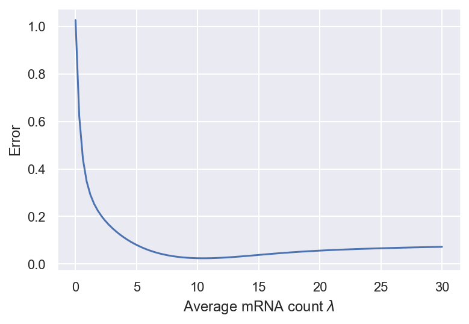

```python
# Determine error for a range of possible lambdas

# Number of points to plot
n_points = 100

# Range of lambdas to test
lambdas_P = np.linspace(0, 30, n_points)

# Initialize an array of error
errors_P = np.zeros(n_points)

# For each lambda, call our err funtion to determine the amount of error
for i in range(n_points):
    errors_P[i] = err(df_P.probability, df_P.mRNA_count, lambdas_P[i])

# Plot the errors over the values of lambda
plt.plot(lambdas_P, errors_P)
plt.ylabel('Error')
plt.xlabel('Average mRNA count $\lambda$')
plt.show()
```

```
[10.60606061]
```

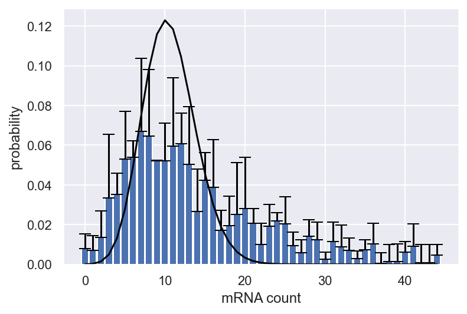

```python
# Index of the optimal lambda
ind_optimal_P = np.where(errors_P == np.min(errors_P))

# Optimal lambda
lambda_fit_P = lambdas_P[ind_optimal_P]

# Show the optimal fit
print(lambda_fit_P)

# Plot histogram with optimal Poisson fit
plt.bar(df_P.mRNA_count, df_P.probability, width=0.9)
plotline, caplines, barlinecols = plt.errorbar(df_P.mRNA_count, df_P.probability,
             yerr= df_P.error,
             ecolor='black',
             capsize=5,
             lolims=True,
             fmt='none',)
caplines[0].set_marker('_')
plt.plot(df_P.mRNA_count, ((lambda_fit_P**df_P.mRNA_count) * np.exp((-1)*lambda_fit_P)) / \
         spec.factorial(df_P.mRNA_count), color = 'black')
plt.xlabel('mRNA count')
_ = plt.ylabel('probability')
```

The probability distribution as defined by a Poisson curve is too densely centered around the mean, whereas the PDR5 gene expression distribution varies considerably across different possible mRNA counts. This is a strong indicator that, in the steady state, this gene exhibits "bursty" transcription. Such a phenomenon is better modeled by a negative binomial distribution (the discrete analog to the continuous Gamma distribution), defined as

$$ P(k) = {k+n-1 \choose n-1} p^n(1-p)^k, $$

where $k$ is the number of mRNA transcripts made in the characteristic lifetime of an mRNA, $n$ is a measure of the frequency of bursts, and $p$ is the probability that a burst in transcription stops.

We now determine the combination of parameters $(n,p)$ for which the negative binomial distribution best fits PDR5 gene expression.

```python
# Define chi-squared error function for negative binomial distribution

def err_nb(dat, count, success, successprob):
    """
    Returns the sum of the errors for the theory curve (given the provided count, success, and success probability parameters)
    versus the provided data (dat).
    """
    theory = spec.comb(count + success - 1, success - 1) * (successprob**success) * (1 - successprob)**count
    return np.sum((theory - dat)**2)
```

```python
# Determine error for possible combinations of (n,p)

# Number of points to plot
n_points = 100

# Range of n (number of successes) to test
n_succ = np.linspace(0, 30, n_points)

# Range of p (success probabilities) to test
p_succ = np.linspace(0, 1, n_points)

# Initialize an array of error
errors_Pnb = np.zeros((n_points, n_points))

# For each lambda, call our err funtion to determine the amount of error
for i in range(n_points):
    for j in range(n_points):
        errors_Pnb[i,j] = err_nb(df_P.probability, df_P.mRNA_count, n_succ[i], p_succ[j])
```

```
[3.33333333]
[0.2020202]
```

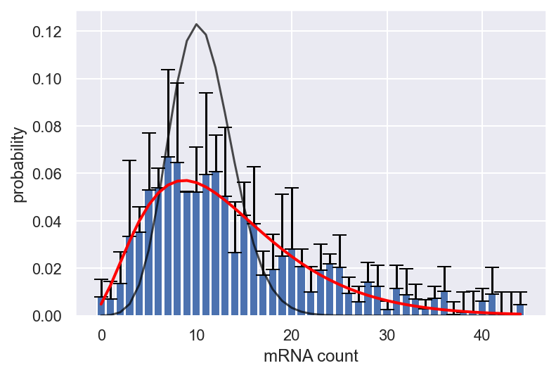

```python
# Index of the optimal
ind_optimal_Pnb = np.where(errors_Pnb == np.min(errors_Pnb))

# Optimal (n,p)
n_fit = n_succ[ind_optimal_Pnb[0]]
p_fit = p_succ[ind_optimal_Pnb[1]]

# Show the optimal fit
print(n_fit)
print(p_fit)

# Plot histogram with optimal poisson vs negative binomial fit
plt.bar(df_P.mRNA_count, df_P.probability, width=0.9)
plotline, caplines, barlinecols = plt.errorbar(df_P.mRNA_count, df_P.probability,
             yerr= df_P.error,
             ecolor='black',
             capsize=5,
             lolims=True,
             fmt='none',)
caplines[0].set_marker('_')

# Poisson
plt.plot(df_P.mRNA_count, ((lambda_fit_P**df_P.mRNA_count) * np.exp((-1)*lambda_fit_P))/ \
         spec.factorial(df_P.mRNA_count), color='black', alpha=0.7)

# Negative binomial
plt.plot(df_P.mRNA_count, spec.comb(df_P.mRNA_count + n_fit - 1, n_fit - 1) * (p_fit)**n_fit * \
         (1-p_fit)**df_P.mRNA_count, color='red', linewidth=2)
plt.xlabel('mRNA count')
_ = plt.ylabel('probability')
```